```python
import matplotlib.pyplot as plt

%matplotlib inline

plt.rcParams['figure.figsize'] = (12, 8)
```

# Datenanalyse mit pandas

[figure not shown]

## Von Rohdaten über DataFrames mit Multi-Indizes zu Panels

### PyCologne, 08.10.2014, Köln

[Henning Dickten](https://www.github.com/hensing)  
pycologne@blobhal.de

# Warum pandas?

**Library Highlights** ([Quelle](http://pandas.pydata.org/))

- A **fast and efficient** DataFrame object for data manipulation **with integrated indexing**;
- Tools for reading and writing data between in-memory data structures and **different formats**: CSV and text files, Microsoft Excel, SQL databases, and the fast HDF5 format;
- Intelligent **data alignment** and integrated handling of **missing data**: gain automatic label-based alignment in computations and easily manipulate messy data into an orderly form;
- Flexible reshaping and pivoting of data sets;
- Intelligent **label-based slicing**, **fancy indexing**, and subsetting of large data sets;
- Columns can be inserted and deleted from data structures for size mutability;
- Aggregating or transforming data with a powerful group by engine allowing split-apply-combine operations on data sets;
- High performance merging and joining of data sets;
- **Hierarchical axis indexing** provides an intuitive way of **working with high-dimensional data in a lower-dimensional data structure**;
- **Time series-functionality**: date range generation and frequency conversion, moving window statistics, moving window linear regressions, date shifting and lagging. Even create domain-specific time offsets and join time series without losing data;
- Highly optimized for performance, with critical code paths written in Cython or C.
- Python with pandas is in use in a wide variety of academic and commercial domains, including Finance, Neuroscience, Economics, Statistics, Advertising, Web Analytics, and more.

# Los gehts:

## Beispiel: CSV der Temparatur verschiedener Computer

```python
import pandas as pd
```

```python
# Beispieldatensatz:
fname = 'temps.log'
!tail -n 5 $fname
```

```
1412586601,zweig10,37
1412586601,Ast1,26
1412586601,zweig09,38
1412586601,zweig06,41
1412586601,zweig07,41
```

```python
# Daten aus CSV in DataFrame einlesen:
data = pd.read_csv(fname, sep=',',
                   names=['timestamp', 'hostname', 'temp'],
                   #index_col=('timestamp', 'hostname'),
                   dtype={'timestamp': int, 'hostname': str, 'temp': int},
                   #parse_dates=['timestamp'],  # doesn't work with timestamps!!!
                   error_bad_lines=True)
type(data)
```

```
pandas.core.frame.DataFrame
```

# Indizierung

```python
data.head(3)  # show first 3 entries, default 5
```

|  | timestamp | hostname | temp |
| --- | --- | --- | --- |
| 0 | 1330934101 | zweig06 | 38 |
| 1 | 1330934101 | zweig08 | 41 |
| 2 | 1330934101 | zweig04 | 38 |

3 rows × 3 columns

```python
data['hostname'].head(3)  # == data.hostname.head(3)
```

```
0    zweig06
1    zweig08
2    zweig04
Name: hostname, dtype: object
```

```python
data.ix[2]
```

```
timestamp    1330934101
hostname        zweig04
temp                 38
Name: 2, dtype: object
```

```python
data.loc[2, ['hostname', 'temp']]
```

```
hostname    zweig04
temp             38
Name: 2, dtype: object
```

## Timestamp (int) -> DatetimeIndex

```python
# timestamp -> datetime:
data['timestamp'].astype('M8[s]').tail(3)
```

```
4927489   2014-10-06 09:10:01
4927490   2014-10-06 09:10:01
4927491   2014-10-06 09:10:01
Name: timestamp, dtype: datetime64[ns]
```

```python
data['dtime'] = data['timestamp'].astype('M8[s]')
data.tail(3)
```

|  | timestamp | hostname | temp | dtime |
| --- | --- | --- | --- | --- |
| 4927489 | 1412586601 | zweig09 | 38 | 2014-10-06 09:10:01 |
| 4927490 | 1412586601 | zweig06 | 41 | 2014-10-06 09:10:01 |
| 4927491 | 1412586601 | zweig07 | 41 | 2014-10-06 09:10:01 |

3 rows × 4 columns

```python
data.drop('timestamp', axis=1, inplace=True)
data.tail(3)
```

|  | hostname | temp | dtime |
| --- | --- | --- | --- |
| 4927489 | zweig09 | 38 | 2014-10-06 09:10:01 |
| 4927490 | zweig06 | 41 | 2014-10-06 09:10:01 |
| 4927491 | zweig07 | 41 | 2014-10-06 09:10:01 |

3 rows × 3 columns

```python
# reindex mit DatetimeIndex:
data.set_index('dtime', inplace=True)
data.tail(3)
```

| dtime | hostname | temp |
| --- | --- | --- |
| 2014-10-06 09:10:01 | zweig09 | 38 |
| 2014-10-06 09:10:01 | zweig06 | 41 |
| 2014-10-06 09:10:01 | zweig07 | 41 |

3 rows × 2 columns

# Multi-Indizes / Hierachical indexing

```python
# hostname -> machine type via regex
remap = {r'\AAst\d+': 'aeste',
         r'\Axena\d+': 'xenen',
         r'\Azweig\d+': 'zweige',
         r'\A(?!(Ast|zweig|xen|aest))\w+[\d-]*': 'andere'}

data['type'] = data['hostname'].replace(regex=remap)
data.head()
```

| dtime | hostname | temp | type |
| --- | --- | --- | --- |
| 2012-03-05 07:55:01 | zweig06 | 38 | zweige |
| 2012-03-05 07:55:01 | zweig08 | 41 | zweige |
| 2012-03-05 07:55:01 | zweig04 | 38 | zweige |
| 2012-03-05 07:55:01 | isabelle | 40 | andere |
| 2012-03-05 07:55:01 | xena5 | 21 | xenen |

5 rows × 3 columns

```python
# set type and hostname as additional index
data.set_index('type', append=True, inplace=True)
data.set_index('hostname', append=True, inplace=True)
data.tail()
```

| dtime | type | hostname | temp |
| --- | --- | --- | --- |
| 2014-10-06 09:10:01 | zweige | zweig10 | 37 |
|  | aeste | Ast1 | 26 |
|  | zweige | zweig09 | 38 |
|  |  | zweig06 | 41 |
|  |  | zweig07 | 41 |

5 rows × 1 columns

```python
type(data.index)
```

```
pandas.core.index.MultiIndex
```

## Indizierung bei MultiIndex:

```python
data.tail()
```

| dtime | type | hostname | temp |
| --- | --- | --- | --- |
| 2014-10-06 09:10:01 | zweige | zweig10 | 37 |
|  | aeste | Ast1 | 26 |
|  | zweige | zweig09 | 38 |
|  |  | zweig06 | 41 |
|  |  | zweig07 | 41 |

5 rows × 1 columns

```python
data.xs('zweig06', level='hostname', drop_level=False).head()
```

| dtime | type | hostname | temp |
| --- | --- | --- | --- |
| 2012-03-05 07:55:01 | zweige | zweig06 | 38 |
| 2012-03-05 08:00:01 | zweige | zweig06 | 38 |
| 2012-03-05 08:05:01 | zweige | zweig06 | 38 |
| 2012-03-05 08:10:02 | zweige | zweig06 | 38 |
| 2012-03-05 08:15:01 | zweige | zweig06 | 38 |

5 rows × 1 columns

```python
## seit pandas 0.14:
# data.loc[(slice(None), slice(None), 'zweig06')]
```

# Analyse mit Multi-Indizes:

```python
# Mittel über hostname
mean_hostname = data.groupby(level='hostname').mean()
mean_hostname.head(3)
```

| hostname | temp |
| --- | --- |
| Ast1 | 45.900189 |
| Ast2 | 47.184190 |
| Ast3 | 49.039549 |

3 rows × 1 columns

```python
# Mittel über hosttype
mean_type = data.groupby(level='type').mean()
mean_type.head()
```

| type | temp |
| --- | --- |
| aeste | 47.097347 |
| andere | 45.564027 |
| xenen | 36.323052 |
| zweige | 47.411616 |

4 rows × 1 columns

```python
# Mittel über hosts pro hosttype, zeitaufgelöst
mean_dtime_type = data.groupby(level=('dtime', 'type')).mean()
mean_dtime_type.tail()
```

| dtime | type | temp |
| --- | --- | --- |
| 2014-10-06 09:05:01 | xenen | 23.000000 |
|  | zweige | 41.222222 |
| 2014-10-06 09:10:01 | aeste | 34.400000 |
|  | xenen | 23.000000 |
|  | zweige | 41.222222 |

5 rows × 1 columns

# Resampling / rolling mean:

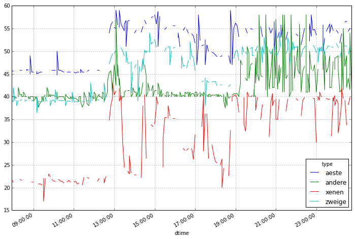

```python
# Mittel über hosts pro hosttype, zeitaufgelöst
# mean_dtime_type = data.groupby(level=('dtime', 'type')).mean()

mean_dtime_type[:1000].unstack()['temp'].plot()
```

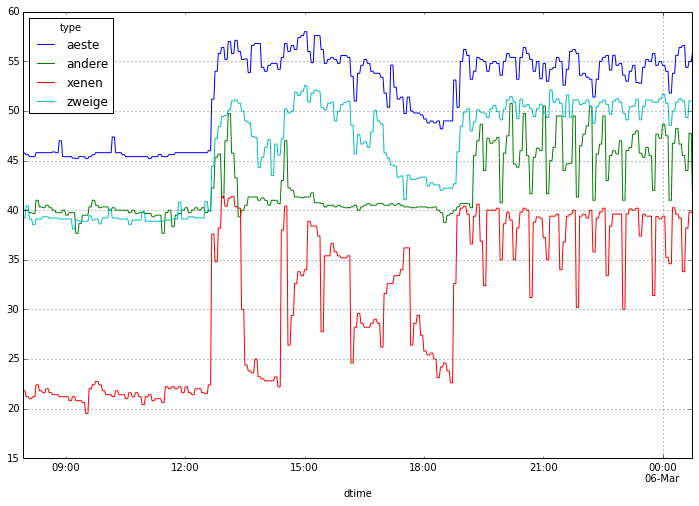

```python
# resampling mit Abtastung 1 / 100s
subset = mean_dtime_type[:1000].unstack()['temp']
subset = subset.resample("100s", fill_method="ffill")
subset.plot()
```

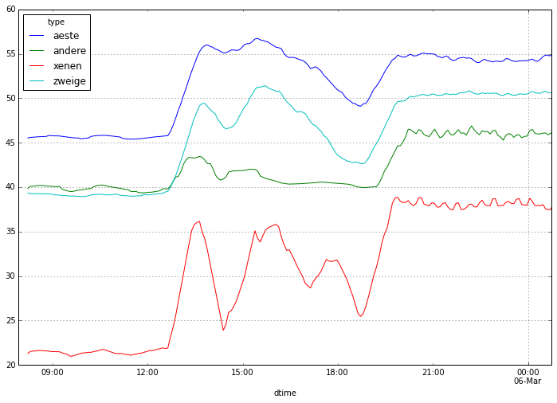

```python
# kleinere Fluktuationen uninteressant -> rolling mean:
# Fensterlänge 36 -> 36 * 100s = 60 min

pd.rolling_mean(subset, window=36, min_periods=12).plot()
```

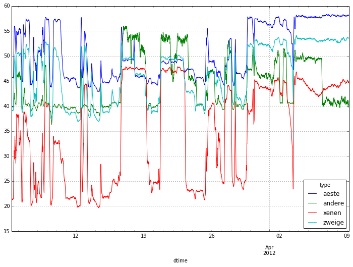

```python
# gleitender Mittelwert über 2h für ca. einen Monat
subset = mean_dtime_type[:50000].unstack()['temp']
subset = subset.resample("100s", fill_method="ffill")
smoothed = pd.rolling_mean(subset, window=72, min_periods=6)
smoothed.plot()
```

# Einfache statistische Analysen

```python
smoothed.describe()
```

| type | aeste | andere | xenen | zweige |
| --- | --- | --- | --- | --- |
| count | 30158.000000 | 30158.000000 | 30158.000000 | 30158.000000 |
| mean | 50.862921 | 44.287391 | 35.177868 | 46.792856 |
| std | 5.241153 | 5.049422 | 9.965652 | 5.538833 |
| min | 42.812500 | 36.305556 | 19.701042 | 36.808796 |
| 25% | 45.790885 | 40.104167 | 24.537934 | 41.137859 |
| 50% | 49.145833 | 41.212384 | 38.414931 | 48.632548 |
| 75% | 56.947135 | 49.121528 | 44.264149 | 52.225468 |
| max | 58.300000 | 56.010417 | 47.865625 | 54.046520 |

8 rows × 4 columns

```python
smoothed.corr()
```

| type | aeste | andere | xenen | zweige |
| --- | --- | --- | --- | --- |
| aeste | 1.000000 | 0.238915 | 0.655138 | 0.908679 |
| andere | 0.238915 | 1.000000 | 0.723648 | 0.519068 |
| xenen | 0.655138 | 0.723648 | 1.000000 | 0.858908 |
| zweige | 0.908679 | 0.519068 | 0.858908 | 1.000000 |

4 rows × 4 columns

# Einfache grafische Auswertung

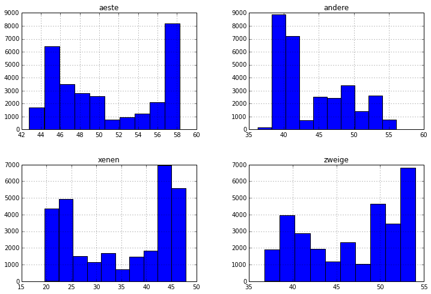

```python
fig = smoothed.hist()
```

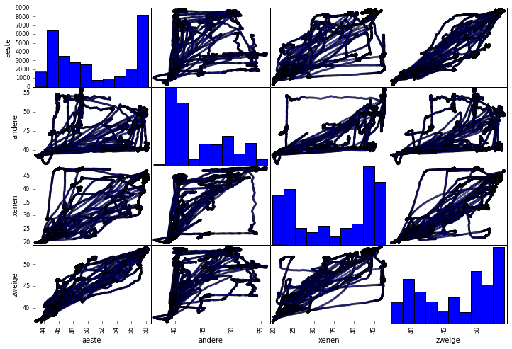

```python
from pandas.tools.plotting import scatter_matrix
fig = scatter_matrix(smoothed)
```

```python
all_smoothed = mean_dtime_type.unstack()['temp']
all_smoothed = all_smoothed.resample("1h", fill_method="ffill")
```

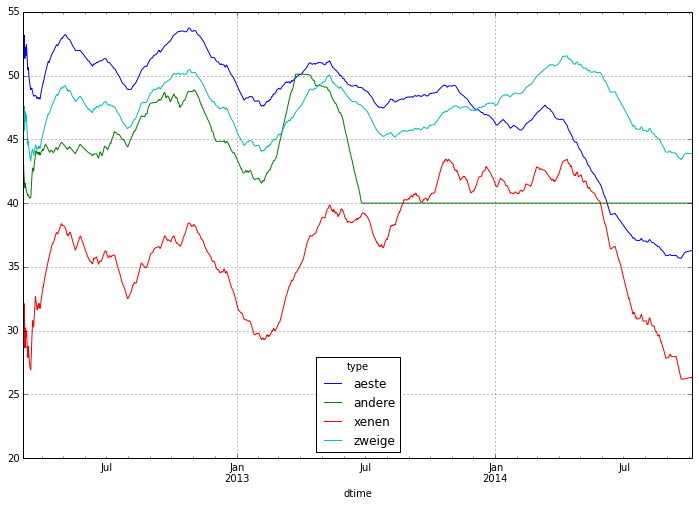

```python
pd.rolling_mean(all_smoothed, window=24 * 31 * 3, min_periods=6).plot()
```

# Tricks: Panel / DataFrames aus Dicts

```python
from collections import defaultdict
ddict = lambda: defaultdict(ddict)
import random

temp = ddict()
```

```python
# Fülle dict(dict(...))
for para1 in ['foo', 'bar', 'blub']:
    for para2 in range(20):
        for para3 in range(8, 15):
            # do some calculation / read files ...
            temp[para1][para2][para3] = random.random()
```

```python
# Konvertiere dict(dict(...)) -> panel
panel = pd.Panel(temp)

# Achsen benennen:
panel.items.name = 'type'
panel.major_axis.name = 'para2'
panel.minor_axis.name = 'para1'

panel
```

```
<class 'pandas.core.panel.Panel'>
Dimensions: 3 (items) x 7 (major_axis) x 20 (minor_axis)
Items axis: bar to foo
Major_axis axis: 8 to 14
Minor_axis axis: 0 to 19
```

## Panels -> DataFrame

```python
# panels bestehen aus DataFrames:
panel['bar'].head()
```

| para1 para2 | 0 | 1 | 2 | 3 | 4 | 5 | 6 | 7 | 8 | 9 | 10 | 11 | 12 | 13 | 14 | 15 | 16 | 17 | 18 | 19 |
| --- | --- | --- | --- | --- | --- | --- | --- | --- | --- | --- | --- | --- | --- | --- | --- | --- | --- | --- | --- | --- |
| 8 | 0.452634 | 0.661609 | 0.389465 | 0.098273 | 0.630689 | 0.996808 | 0.066930 | 0.907631 | 0.321576 | 0.640331 | 0.248452 | 0.178864 | 0.911142 | 0.426302 | 0.349360 | 0.084409 | 0.466592 | 0.422254 | 0.558918 | 0.817036 |
| 9 | 0.766128 | 0.200101 | 0.566535 | 0.689536 | 0.486744 | 0.615849 | 0.671780 | 0.946859 | 0.736955 | 0.645617 | 0.910303 | 0.505518 | 0.792108 | 0.072233 | 0.649790 | 0.357478 | 0.701292 | 0.773938 | 0.909106 | 0.909726 |
| 10 | 0.237982 | 0.229560 | 0.508203 | 0.195491 | 0.635997 | 0.340997 | 0.635385 | 0.556657 | 0.667104 | 0.511117 | 0.235042 | 0.388006 | 0.956348 | 0.228922 | 0.376922 | 0.136381 | 0.173271 | 0.474445 | 0.939267 | 0.817309 |
| 11 | 0.909058 | 0.313479 | 0.483083 | 0.971288 | 0.845737 | 0.309853 | 0.460069 | 0.026056 | 0.413083 | 0.964312 | 0.803718 | 0.120050 | 0.412057 | 0.439821 | 0.474462 | 0.218472 | 0.635578 | 0.342892 | 0.142384 | 0.902863 |
| 12 | 0.298156 | 0.017565 | 0.002108 | 0.400396 | 0.433372 | 0.295304 | 0.754458 | 0.846440 | 0.920205 | 0.738052 | 0.131014 | 0.486283 | 0.679913 | 0.865638 | 0.784458 | 0.527470 | 0.131490 | 0.634700 | 0.481132 | 0.135271 |

5 rows × 20 columns

```python
# panel -> DataFrame:
panel.to_frame().head()
```

| para2 | type para1 | bar | blub | foo |
| --- | --- | --- | --- | --- |
| 8 | 0 | 0.452634 | 0.085523 | 0.208225 |
|  | 1 | 0.661609 | 0.096135 | 0.393855 |
|  | 2 | 0.389465 | 0.540882 | 0.583333 |
|  | 3 | 0.098273 | 0.164150 | 0.025681 |
|  | 4 | 0.630689 | 0.414112 | 0.419237 |

5 rows × 3 columns

## Save / Load

```python
# save
panel.to_hdf('fname', 'my_key_in_hdf')

# load
store = pd.HDFStore('fname')
store
```

```
<class 'pandas.io.pytables.HDFStore'>
File path: fname
/my_key_in_hdf            wide         (shape->[3,7,20])
```

### Andere Formate:

```python
panel.to_pickle('dump')
```

```python
panel.to_excel('OMG_I_use_excel.xls')
```

# Datenanalyse mit pandas

[figure not shown]

## Von Rohdaten über DataFrames mit Multi-Indizes zu Panels

### PyCologne, 08.10.2014, Köln

[Henning Dickten](https://www.github.com/hensing)  
pycologne@blobhal.de